# Avance del proyecto final: riesgo de pérdida en la serie GBP/USD

Computación Estadística 2026-II, Universidad Nacional de Colombia. Grupo 2

[Adriana Jaimes, Crisdailyn Rey, John Rincón, Maria Vega]

28 de octubre de 2026

# 1 Introducción y datos

El proyecto estudia cuánto puede perderse en un día o en una semana al mantener un activo y qué tan confiable es esa cifra. Nuestro grupo trabaja con la serie del tipo de cambio **GBP/USD**, a partir del archivo `retornos_diarios_12_series.csv` entregado por la docente. Según la guía, la serie cubre del 2 de enero de 1980 al 21 de mayo de 1987 y su retorno diario es $100\,(\ln P_t-\ln P_{t-1})$, en porcentaje. El archivo no trae fechas, solo el número de día $t$; el período se toma de la guía. Se usan exclusivamente las 1866 observaciones de `GBP/USD`, que coinciden con las 1.866 que indica la guía, con $t$ consecutivo de 1 a 1866 y sin valores faltantes.

Los retornos tienen media -0.0156 y desviación estándar 0.7592; su asimetría es 0.2977 y su curtosis en exceso es 3.0563, lo que indica colas más pesadas que las de una normal. La Figura 1 muestra que los movimientos grandes tienden a agruparse en rachas, una señal de volatilidad agrupada que condiciona los supuestos de independencia de los métodos posteriores.

**Tratamiento de los ceros.** 75 retornos valen exactamente cero (4.019 % de la serie). Las distribuciones Weibull y lognormal solo admiten valores estrictamente positivos, de modo que la Fase A se construye sobre $x_i=|r_i|$ para los $r_i\neq 0$, que son 1791 datos. Se excluyen solo para la Fase A. En B2 se usan los retornos originales completos, con los ceros. La consecuencia es que el modelo ajustado nunca produce un retorno exactamente cero, mientras que en los datos ocurre en el 4.0 % de los días. Esto es una limitación del modelo.

Además, el menor $|r|$ no nulo es 0.0198, y bajo la Weibull ajustada se esperarían unos 37 valores por debajo de ese mínimo, pero no hay ninguno. Esto es compatible con que los precios originales estén registrados en pasos discretos y que los movimientos muy pequeños figuren como cero; es solo una hipótesis, que no podemos verificar con los archivos disponibles.

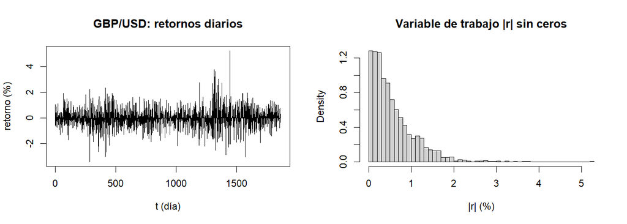

Retornos diarios de GBP/USD (izquierda) y variable de trabajo |r| sin ceros (derecha).

# 2 Fase A: simulación y generación de variables

## 2.1 Estimación por máxima verosimilitud

Se ajustaron por máxima verosimilitud, con implementación propia, la lognormal (solución cerrada: $\hat\mu=\overline{\ln x}$, $\hat\sigma^2=\overline{(\ln x-\hat\mu)^2}$) y la Weibull de forma $k$ y escala $\lambda$. Para la Weibull, $\hat\lambda^k=\overline{x^k}$ y la forma $\hat k$ es la raíz de
$$g(k)=\frac{\sum x_i^k\ln x_i}{\sum
x_i^k}-\frac1k-\overline{\ln x}=0,$$
que se resolvió con el método de Newton. Como $g'(k)>0$ para todo $k>0$, la raíz es única. Newton convergió en pocas iteraciones desde varios valores iniciales. Como comprobación, `MASS::fitdistr` (solo verificación) coincide con nuestros parámetros hasta la quinta cifra decimal en la Weibull.

Parámetros estimados por máxima verosimilitud y AIC (m = 1791).

| Familia | Parámetros | Log-verosimilitud | AIC |
| --- | --- | --- | --- |
| Lognormal | mu = -1.0035, sigma = 1.0411 | -816.10 | 1636.21 |
| Weibull | k = 1.1367, lambda = 0.5997 | -766.13 | 1536.26 |

## 2.2 Generación y validación

La Weibull se simula por transformada inversa, $X=\lambda[-\ln U]^{1/k}$, y la lognormal con una normal estándar generada por Box-Muller, $X=\exp(\mu+\sigma Z)$ con $Z=\sqrt{-2\ln U_1}\cos(2\pi U_2)$. Solo se usa el generador uniforme base. Se comprobó que $F(X)$ es uniforme en la muestra Weibull y que Box-Muller reproduce media 0 y varianza 1 con muestras grandes. Para validar, se generó una muestra sintética 20 veces mayor que la real ($N=3.582\times 10^{4}$) por familia.

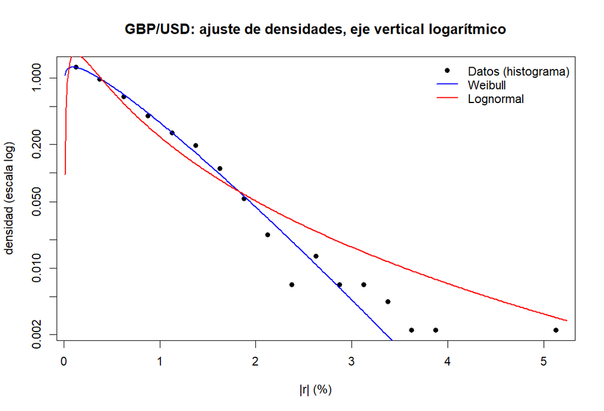

Ajuste de las densidades con eje vertical logarítmico. Cada punto aislado en la cola corresponde a muy pocas observaciones.

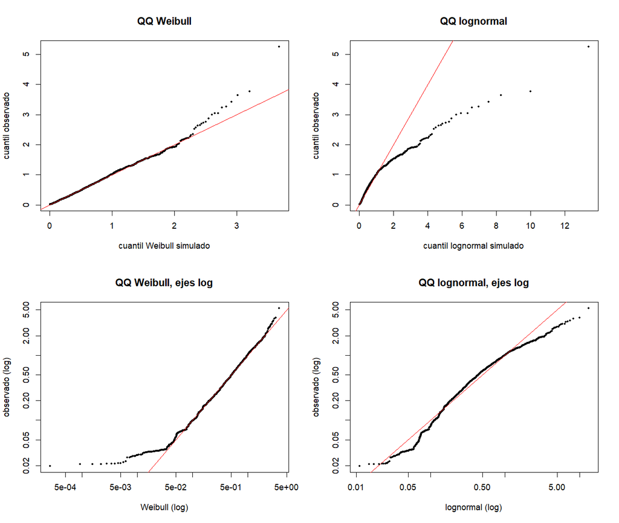

Gráficos cuantil-cuantil: cuantiles observados frente a cuantiles de las muestras sintéticas (fila inferior: ejes logarítmicos).

Cuantiles 50, 90 y 99 de |r|.

| Cuantil | Observado | Weibull simulada | Weibull teórica | Lognormal simulada |
| --- | --- | --- | --- | --- |
| 50 % | 0.4231 | 0.4346 | 0.4344 | 0.3681 |
| 90 % | 1.2776 | 1.2513 | 1.2490 | 1.4242 |
| 99 % | 2.3257 | 2.2870 | 2.2981 | 4.2156 |

La distancia de Kolmogorov-Smirnov, calculada manualmente entre la muestra observada y la sintética, es 0.0221 para la Weibull y 0.0573 para la lognormal (frente a la teórica, 0.0222 y 0.0579). Como los parámetros se estimaron con los mismos datos, estos valores se interpretan como medidas de distancia y no como un contraste formal.

Excedencias de la cola bajo el modelo Weibull.

| Cuantil de la Weibull | Valor | Datos que lo superan | Esperados si el modelo fuera exacto |
| --- | --- | --- | --- |
| 99 % | 2.298 | 19 | 17.9 |
| 99.5 % | 2.600 | 15 | 9.0 |
| 99.9 % | 3.283 | 4 | 1.8 |

**Interpretación.** La Weibull sigue de cerca a los datos en el centro y hasta el cuantil 99 %, mientras que la lognormal, aunque tiene la cola teórica más pesada, la **sobreestima** con fuerza: su cuantil 99 % simulado es 4.22 frente a 2.33 observado. Por otro lado, la Weibull subestima algo el extremo de la cola: en el último 0.5 % de los días hay más excedencias de las esperadas (Tabla 3), y el mayor retorno absoluto observado, 5.24, es muy poco probable bajo el modelo. Esto es relevante para el evento raro de B1.

**Retornos con signo.** Para simular retornos con signo se asigna $+$ o $-$ con probabilidad 1/2, independiente de la magnitud. Es un supuesto del modelo (simetría y signos independientes), no una propiedad demostrada de los datos: en la muestra hay 860 retornos positivos y 931 negativos.

# 3 Fase B: integración y remuestreo (avance)

## 3.1 B1: Monte Carlo y muestreo por importancia

La propuesta de muestreo por importancia genera cada $X_j\sim$ Weibull$(k,\,c\lambda)$ con $c=2$ y declara un día como de pérdida con probabilidad $q=0.85$ en vez de 1/2. El peso es $W=\prod_{j=1}^5 c^{k}\exp\{-(x_j/\lambda)^k+(x_j/(c\lambda))^k\}\,(0.5/q)^{N_p}(0.5/(1-q))^{5-N_p}$, con $N_p$ el número de días de pérdida. El estimador es el promedio de $\mathbf 1\{S_5>u\}W$, insesgado porque $E_g[\mathbf 1\{S_5>u\}W]=p$. Los parámetros $(c,q)$ se eligieron con un piloto sobre una rejilla de propuestas.

Estimación de P(pérdida a 5 días > 5.67) con N = 100000 simulaciones por método.

| Método | Estimación de p | Error estándar |
| --- | --- | --- |
| Monte Carlo simple | 0.000980 | 9.89e-05 |
| Muestreo por importancia | 0.000991 | 1.07e-05 |
| Referencia (4e6) | 0.000980 | 1.56e-05 |

La reducción de varianza lograda es de 85.4 veces: el muestreo por importancia con $N=10^{5}$ equivale a un Monte Carlo simple de unos 8.540.000 simulaciones. Ambas estimaciones son compatibles con la referencia (a menos de un error estándar de diferencia combinada).

Piloto de propuestas. Un cociente menor que 1 indica que la propuesta aumenta la varianza.

| c | q | Estimación | Var MC / Var IS |
| --- | --- | --- | --- |
| 0.7 | 0.50 | 0.000822 | 0.02 |
| 1.0 | 0.50 | 0.001115 | 0.88 |
| 2.0 | 0.50 | 0.001001 | 14.88 |
| 4.0 | 0.50 | 0.000997 | 5.22 |
| 8.0 | 0.50 | 0.001116 | 0.37 |
| 0.7 | 0.85 | 0.000807 | 0.11 |
| 1.0 | 0.85 | 0.001040 | 3.14 |
| 2.0 | 0.85 | 0.000987 | 80.97 |
| 4.0 | 0.85 | 0.001011 | 29.57 |
| 8.0 | 0.85 | 0.000993 | 2.42 |

El piloto ilustra por qué la propuesta debe elegirse con cuidado: con $c=0.7$ la varianza es mucho mayor que la del Monte Carlo simple, y con $c=8$ el cociente también cae por debajo de 1 (pesos muy dispersos). Limitación: el modelo supone días independientes, lo que contradice la volatilidad agrupada observada, y la Weibull subestima el extremo de la cola; la probabilidad real de una racha de pérdidas podría ser mayor que la del modelo.

## 3.2 B2: bootstrap percentil (avance)

Sobre los retornos originales, con los 75 ceros incluidos, se estudian la desviación estándar y el VaR al 99 % diario (cuantil 99 % de $-r$). Se usaron $B=5000$ réplicas con remuestreo con reemplazo programado a mano, y el intervalo percentil del 95 % toma los cuantiles 2.5 % y 97.5 % de las réplicas.

Bootstrap percentil (B = 5000) sobre los retornos originales.

| Estadístico | Estimación | Sesgo bootstrap | EE bootstrap | IC 95 % inf. | IC 95 % sup. |
| --- | --- | --- | --- | --- | --- |
| Desv. estándar | 0.7592 | -0.0002 | 0.0200 | 0.7214 | 0.7984 |
| VaR 99% | 1.9001 | 0.0148 | 0.0973 | 1.7325 | 2.1420 |

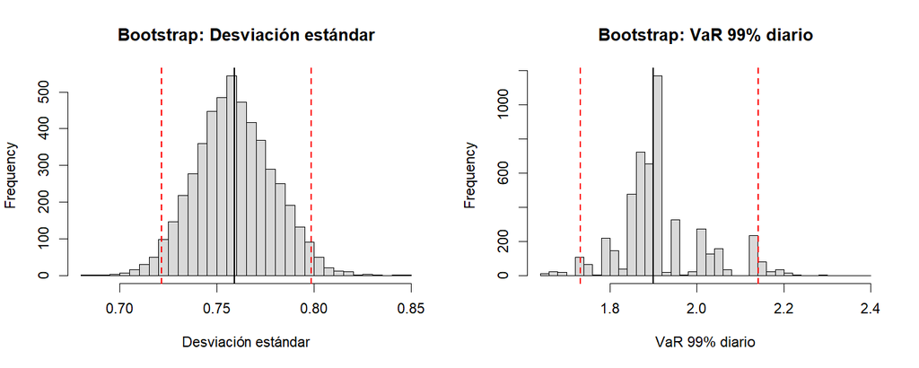

Distribución bootstrap de la desviación estándar y del VaR 99 %. La línea negra es la estimación original y las rojas, el intervalo percentil.

La desviación estándar es estimada con un error relativo de 2.6 %, y su distribución bootstrap es suave y casi simétrica. El VaR al 99 % es mucho menos preciso (error relativo 5.1 %), porque depende de las pocas pérdidas de la cola, y su distribución bootstrap es irregular: el cuantil de una remuestra solo puede tomar valores próximos a las pérdidas observadas más grandes, entre las que hay huecos. El sesgo bootstrap es pequeño frente al error estándar en ambos casos. Como el remuestreo ordinario supone observaciones independientes, estos intervalos pueden ser demasiado optimistas si la volatilidad agrupada es fuerte. El jackknife, el intervalo BCa y los intervalos asintóticos se desarrollarán en la entrega final.

# 4 Referencias

# 5 Anexo: código

## 5.1 funciones_A.R

```r
# =====================================================================
# funciones_A.R - Generadores de la Fase A (SOLO definiciones, sin salida)
# Solo se usa runif() como generador base y funciones elementales.
# =====================================================================

# Weibull(k forma, lam escala) por TRANSFORMADA INVERSA
# F(x) = 1 - exp(-(x/lam)^k)  =>  F^{-1}(u) = lam * (-log(1 - u))^(1/k)
# Como 1 - U tiene la misma distribución que U, se usa -log(U).
rweibull_ti <- function(n, k, lam) {
  u <- runif(n)
  lam * (-log(u))^(1 / k)
}

# Normal estándar por BOX-MULLER (a partir de dos uniformes independientes)
rnorm_bm <- function(n) {
  u1 <- runif(n); u2 <- runif(n)
  sqrt(-2 * log(u1)) * cos(2 * pi * u2)
}

# Lognormal(mu, sigma): X = exp(mu + sigma * Z), Z ~ N(0,1)
rlnorm_bm <- function(n, mu, sigma) {
  exp(mu + sigma * rnorm_bm(n))
}

# Función de distribución acumulada de la Weibull (para verificaciones)
pweibull_propia <- function(x, k, lam) 1 - exp(-(x / lam)^k)

# Signos +/-1 con probabilidad 1/2 cada uno (supuesto del modelo, Fase A.4)
signos <- function(n) ifelse(runif(n) < 0.5, 1, -1)
```

## 5.2 01_datos.R

```r
# TAREA 1 - Carga de datos, ceros y variable de trabajo (GBP/USD)
# Proyecto final - Computación Estadística 2026-II - GRUPO 2
# Ejecutar desde la carpeta raíz del proyecto, con esta estructura:
#   proyecto/
#     data/retornos_diarios_12_series.csv
#     R/01_datos.R
# =====================================================================

set.seed(2026)   # semilla fija (aquí aún no se simula; se deja desde el inicio)

# ---- 1. Lectura con ruta RELATIVA -----------------------------------
archivo <- "retornos_diarios_12_series.csv"
candidatos <- c(file.path("data", archivo), archivo)   # ambas son rutas relativas
ruta <- candidatos[file.exists(candidatos)][1]
if (is.na(ruta)) {
  stop("No encuentro '", archivo, "'. Carpeta de trabajo actual: ", getwd(),
       "\nPonga el CSV en 'data/' o en esa carpeta, o cambie la carpeta de trabajo ",
       "(RStudio: Session > Set Working Directory > To Source File Location).")
}
cat("Leyendo:", ruta, "\n")
datos <- read.csv(ruta, stringsAsFactors = FALSE, encoding = "UTF-8")

cat("Columnas:", names(datos), "\n")
cat("Series disponibles en el archivo:\n")
print(table(datos$serie))

# ---- 2. Filtro: SOLO GBP/USD, ordenada en el tiempo -----------------
gbp <- datos[datos$serie == "GBP/USD", ]
gbp <- gbp[order(gbp$t), ]
r   <- gbp$retorno_pct          # retornos originales (CON ceros): se usan en B2

# ---- 3. Verificaciones contra la guía --------------------------------
n <- length(r)
cat("\n== Verificaciones ==\n")
cat("n observaciones (guía: 1866):", n, "\n")
cat("t va de", min(gbp$t), "a", max(gbp$t), "\n")
cat("t consecutivo sin saltos:", all(diff(gbp$t) == 1), "\n")
cat("valores faltantes (NA):", sum(is.na(r)), "\n")

# ---- 4. Ceros exactos -------------------------------------------------
es_cero  <- (r == 0)            # TRUE si el retorno es EXACTAMENTE 0
n_ceros  <- sum(es_cero)
pct_ceros <- 100 * n_ceros / n
cat("\n== Ceros exactos ==\n")
cat("cantidad de ceros:", n_ceros, "\n")
cat(sprintf("porcentaje de ceros: %.3f %%\n", pct_ceros))
cat("menor |r| entre los no nulos:", min(abs(r[!es_cero])), "\n")
cat("pares de ceros en días consecutivos:",
    sum(es_cero[-1] & es_cero[-n]), "\n")

# ---- 5. Variable de trabajo de la Fase A: |r| sin ceros -------------
x <- abs(r[!es_cero])
cat("\n== Variable de trabajo x = |r| (sin ceros) ==\n")
cat("tamaño m:", length(x), "\n")
cat("media:", mean(x), " desv.est.:", sd(x), "\n")
cat("mínimo:", min(x), " máximo:", max(x), "\n")
cat("cuantiles 50, 90, 99:", quantile(x, c(0.50, 0.90, 0.99), type = 7), "\n")
cat("retornos > 0:", sum(r > 0), "  retornos < 0:", sum(r < 0), "\n")

# ---- 6. Estadísticos descriptivos de los retornos originales --------
cat("\n== Retornos originales (con ceros) ==\n")
cat("media:", mean(r), " desv.est.:", sd(r), "\n")
m2 <- mean((r - mean(r))^2)
cat("asimetría:", mean((r - mean(r))^3) / m2^1.5, "\n")
cat("curtosis en exceso:", mean((r - mean(r))^4) / m2^2 - 3, "\n")

# ---- 7. Gráfico exploratorio ----------------------------------------
dir.create("figuras", showWarnings = FALSE)
png("figuras/01_exploracion.png", width = 1400, height = 500, res = 130)
par(mfrow = c(1, 2))
plot(gbp$t, r, type = "h", xlab = "t (día)", ylab = "retorno (%)",
     main = "GBP/USD: retornos diarios")
hist(x, breaks = 60, freq = FALSE, xlab = "|r| (%)",
     main = "Variable de trabajo |r| sin ceros")
dev.off()
cat("\nFigura guardada en figuras/01_exploracion.png\n")
```

## 5.3 02_mle.R

```r
# =====================================================================
# TAREA 2 - Máxima verosimilitud: lognormal (forma cerrada) y Weibull (Newton)
# Proyecto final - Computación Estadística 2026-II - GRUPO 2 - GBP/USD
# Ejecutar desde la misma carpeta que 01_datos.R (ver instrucciones previas)
# =====================================================================
set.seed(2026)

# ---- 0. Datos (mismo procedimiento de la tarea 1) --------------------
archivo <- "retornos_diarios_12_series.csv"
candidatos <- c(file.path("data", archivo), archivo)
ruta <- candidatos[file.exists(candidatos)][1]
if (is.na(ruta)) stop("No encuentro el CSV. Carpeta actual: ", getwd())
datos <- read.csv(ruta, stringsAsFactors = FALSE, encoding = "UTF-8")
gbp <- datos[datos$serie == "GBP/USD", ]
gbp <- gbp[order(gbp$t), ]
r <- gbp$retorno_pct
x <- abs(r[r != 0])          # variable de trabajo
m <- length(x)
lx <- log(x)                 # logaritmos: se usan en ambas familias
cat("m =", m, "\n")

# ---- 1. LOGNORMAL: solución cerrada ----------------------------------
# ln X ~ N(mu, sigma^2)  =>  mu_hat = media(ln x),  sigma2_hat = media((ln x - mu_hat)^2)
mu_ln    <- mean(lx)
sigma_ln <- sqrt(mean((lx - mu_ln)^2))        # divisor m (MLE), no m-1

loglik_lognormal <- function(mu, sigma, x) {
  l <- log(x)
  sum(-l - log(sigma) - 0.5 * log(2 * pi) - (l - mu)^2 / (2 * sigma^2))
}
ll_ln  <- loglik_lognormal(mu_ln, sigma_ln, x)
aic_ln <- 2 * 2 - 2 * ll_ln                    # 2 parámetros

# ---- 2. WEIBULL: Newton para la forma k -------------------------------
# Ecuación de verosimilitud (perfil): g(k) = S1/S0 - 1/k - mean(ln x) = 0
#   S0 = sum(x^k),  S1 = sum(x^k ln x),  S2 = sum(x^k (ln x)^2)
# g'(k) = (S2*S0 - S1^2)/S0^2 + 1/k^2
g_weibull <- function(k, x) {
  l  <- log(x)
  xk <- x^k
  S0 <- sum(xk); S1 <- sum(xk * l); S2 <- sum(xk * l^2)
  c(g  = S1 / S0 - 1 / k - mean(l),
    gp = (S2 * S0 - S1^2) / S0^2 + 1 / k^2)
}

newton_weibull <- function(x, k0, tol = 1e-12, max_iter = 100) {
  k <- k0
  hist <- data.frame(iter = 0, k = k0, g = unname(g_weibull(k0, x)["g"]))
  for (it in 1:max_iter) {
    v  <- g_weibull(k, x)
    kn <- unname(k - v["g"] / v["gp"])      # paso de Newton (unname: evita nombres heredados)
    if (!is.finite(kn) || kn <= 0) kn <- k / 2   # protección: k debe ser > 0
    hist <- rbind(hist, data.frame(iter = it, k = unname(kn),
                                   g = unname(g_weibull(kn, x)["g"])))
    if (abs(kn - k) < tol) { k <- kn; break }
    k <- kn
  }
  list(k = unname(k), iter = it, hist = hist)
}

# Valor inicial: Var(ln X) = pi^2/(6 k^2) para la Weibull => k ~ 1.2 / sd(ln x)
# (aproximación mía para arrancar; no es parte de la guía)
k0 <- 1.2 / sqrt(mean((lx - mean(lx))^2))
nw <- newton_weibull(x, k0)
k_w   <- nw$k
lam_w <- (mean(x^k_w))^(1 / k_w)             # lambda_hat^k = media(x^k)

loglik_weibull <- function(k, lam, x) {
  m <- length(x)
  m * log(k) - m * k * log(lam) + (k - 1) * sum(log(x)) - sum((x / lam)^k)
}
ll_w  <- loglik_weibull(k_w, lam_w, x)
aic_w <- 2 * 2 - 2 * ll_w

cat("\n== Historial de Newton (Weibull) ==\n")
print(nw$hist, row.names = FALSE, digits = 10)

# ---- 3. Verificaciones propias (sin librerías) -------------------------
cat("\n== Verificaciones propias ==\n")
cat("g(k_hat) (debe ser ~0):", g_weibull(k_w, x)["g"], "\n")
# El máximo del perfil debe estar en k_hat: comparamos con puntos vecinos
perfil <- function(k) {
  lam <- (mean(x^k))^(1 / k)
  loglik_weibull(k, lam, x)
}
cat("perfil en k_hat-0.05, k_hat, k_hat+0.05:",
    perfil(k_w - 0.05), perfil(k_w), perfil(k_w + 0.05), "\n")
# Robustez al valor inicial
for (k_ini in c(0.3, 1, 3)) {
  cat("inicio", k_ini, "-> k =", newton_weibull(x, k_ini)$k, "\n")
}

# ---- 4. Tabla de resultados ---------------------------------------------
tabla <- data.frame(
  Familia   = c("Lognormal", "Weibull"),
  Parametro1 = c(mu_ln, k_w),        # lognormal: mu ; Weibull: forma k
  Parametro2 = c(sigma_ln, lam_w),   # lognormal: sigma ; Weibull: escala lambda
  logLik    = c(ll_ln, ll_w),
  AIC       = c(aic_ln, aic_w)
)
cat("\n== Resultados (oficiales: implementación propia) ==\n")
print(tabla, row.names = FALSE, digits = 8)
cat("Lognormal: (mu, sigma) | Weibull: (k forma, lambda escala)\n")
cat("Delta AIC (lognormal - Weibull):", aic_ln - aic_w, "\n")

# ---- 5. Comparación con librería (SOLO VERIFICACIÓN, no produce resultados) ----
cat("\n== Verificación con MASS::fitdistr (NO es el resultado oficial) ==\n")
res <- tryCatch({
  f_w  <- MASS::fitdistr(x, "weibull")
  f_ln <- MASS::fitdistr(x, "lognormal")
  print(rbind(
    Weibull_propio    = c(forma = k_w, escala = lam_w),
    Weibull_fitdistr  = unname(f_w$estimate)
  ))
  print(rbind(
    Lognormal_propio   = c(meanlog = mu_ln, sdlog = sigma_ln),
    Lognormal_fitdistr = unname(f_ln$estimate)
  ))
}, error = function(e) cat("MASS no disponible:", conditionMessage(e), "\n"))

# ---- 6. Guardar resultados para las tareas siguientes ----------------------
dir.create("resultados", showWarnings = FALSE)
saveRDS(list(mu_ln = mu_ln, sigma_ln = sigma_ln, k_w = k_w, lam_w = lam_w,
             ll_ln = ll_ln, ll_w = ll_w, aic_ln = aic_ln, aic_w = aic_w),
        "resultados/params_A.rds")
cat("\nGuardado: resultados/params_A.rds\n")
```

## 5.4 03_generadores.R

```r
# =====================================================================
# TAREA 3 - Generadores de variables aleatorias y comprobaciones básicas
# Proyecto final - Computación Estadística 2026-II - GRUPO 2 - GBP/USD
# Requiere: funciones_A.R y resultados/params_A.rds (de 02_mle.R)
# =====================================================================
set.seed(2026)
source("funciones_A.R")
p <- readRDS("resultados/params_A.rds")
k <- p$k_w; lam <- p$lam_w; mu <- p$mu_ln; sg <- p$sigma_ln

# Tamaño de la muestra sintética: unas 20 veces el de la muestra real (m = 1791)
m  <- 1791
N  <- 20 * m
cat("N =", N, "\n")

# ---- 1. Normal estándar por Box-Muller --------------------------------
z <- rnorm_bm(N)
cat("\n== Box-Muller ==\n")
cat("media (teórica 0):", mean(z), "\n")
cat("varianza (teórica 1):", mean((z - mean(z))^2), "\n")
cat("curtosis en exceso (teórica 0):",
    mean((z - mean(z))^4) / mean((z - mean(z))^2)^2 - 3, "\n")

# ---- 2. Weibull por transformada inversa ------------------------------
xw <- rweibull_ti(N, k, lam)
G  <- function(a) exp(lgamma(a))                       # Gamma(a) vía lgamma
mean_w <- lam * G(1 + 1 / k)
sd_w   <- lam * sqrt(G(1 + 2 / k) - G(1 + 1 / k)^2)
q_w    <- function(pp) lam * (-log(1 - pp))^(1 / k)   # cuantiles teóricos
cat("\n== Weibull (transformada inversa) ==\n")
cat("media simulada / teórica:", mean(xw), "/", mean_w, "\n")
cat("desv.est. simulada / teórica:", sd(xw), "/", sd_w, "\n")
cat("cuantiles 50,90,99 simulados:", quantile(xw, c(.5, .9, .99)), "\n")
cat("cuantiles 50,90,99 teóricos :", q_w(c(.5, .9, .99)), "\n")
# Verificación clave: F(X) debe ser Uniforme(0,1)
uu <- pweibull_propia(xw, k, lam)
cat("F(X): media (0.5) y varianza (1/12 = 0.08333):", mean(uu), mean((uu - mean(uu))^2), "\n")

# ---- 3. Lognormal vía Box-Muller + exp(mu + sigma Z) -------------------
xl <- rlnorm_bm(N, mu, sg)
cat("\n== Lognormal (Box-Muller) ==\n")
cat("media simulada / teórica:", mean(xl), "/", exp(mu + sg^2 / 2), "\n")
cat("mediana simulada / teórica:", median(xl), "/", exp(mu), "\n")
cat("media de ln X (mu) y desv.est. de ln X (sigma):", mean(log(xl)), sd(log(xl)), "\n")

# ---- 4. Signos ---------------------------------------------------------
s <- signos(N)
cat("\n== Signos ==\n")
cat("proporción de +1 (teórica 0.5):", mean(s == 1), "\n")
cat("media de los retornos simulados con signo (Weibull):", mean(s * xw), "\n")
```

## 5.5 04_validacion.R

```r
# =====================================================================
# TAREA 4 - Validación: gráfico de ajuste (eje log), QQ, KS a mano, cuantiles
# Proyecto final - Computación Estadística 2026-II - GRUPO 2 - GBP/USD
# Requiere: funciones_A.R y resultados/params_A.rds
# =====================================================================
set.seed(2026)
source("funciones_A.R")
p <- readRDS("resultados/params_A.rds")
k <- p$k_w; lam <- p$lam_w; mu <- p$mu_ln; sg <- p$sigma_ln

# ---- 0. Datos ------------------------------------------------------------
archivo <- "retornos_diarios_12_series.csv"
candidatos <- c(file.path("data", archivo), archivo)
ruta <- candidatos[file.exists(candidatos)][1]
if (is.na(ruta)) stop("No encuentro el CSV. Carpeta actual: ", getwd())
datos <- read.csv(ruta, stringsAsFactors = FALSE, encoding = "UTF-8")
gbp <- datos[datos$serie == "GBP/USD", ]; gbp <- gbp[order(gbp$t), ]
r <- gbp$retorno_pct
x <- abs(r[r != 0]); m <- length(x)
xs <- sort(x)                                   # observados ordenados

# ---- 1. Muestras sintéticas (20 veces el tamaño de la real) ----------------
N  <- 20 * m
yw <- sort(rweibull_ti(N, k, lam))              # Weibull (familia elegida por AIC)
yl <- sort(rlnorm_bm(N, mu, sg))                # lognormal (se valida también, para comparar)

# ---- 2. Densidades teóricas (fórmulas propias) --------------------------------
dweibull_propia <- function(v, k, lam) (k / lam) * (v / lam)^(k - 1) * exp(-(v / lam)^k)
dlnorm_propia   <- function(v, mu, s) exp(-(log(v) - mu)^2 / (2 * s^2)) / (v * s * sqrt(2 * pi))

# ---- 3. Gráfico de ajuste con eje vertical logarítmico ---------------------------
dir.create("figuras", showWarnings = FALSE)
h <- hist(x, breaks = seq(0, ceiling(max(x) * 4) / 4, by = 0.25), plot = FALSE)
ok <- h$density > 0                              # el log no admite densidad 0
grid_x <- seq(0.01, max(x), length.out = 400)
png("figuras/02_ajuste_log.png", width = 1100, height = 750, res = 130)
plot(h$mids[ok], h$density[ok], log = "y", pch = 16,
     xlab = "|r| (%)", ylab = "densidad (escala log)",
     main = "GBP/USD: ajuste de densidades, eje vertical logarítmico")
lines(grid_x, dweibull_propia(grid_x, k, lam), lwd = 2, col = "blue")
lines(grid_x, dlnorm_propia(grid_x, mu, sg),  lwd = 2, col = "red")
legend("topright", c("Datos (histograma)", "Weibull", "Lognormal"),
       pch = c(16, NA, NA), lty = c(NA, 1, 1), lwd = c(NA, 2, 2),
       col = c("black", "blue", "red"), bty = "n")
dev.off()

# ---- 4. QQ-plot (cuantiles observados vs sintéticos) -------------------------------
pi_ <- (1:m - 0.5) / m                           # probabilidades de los m observados
cuant_sint <- function(ysorted, pp) ysorted[ceiling(pp * length(ysorted))]
qw <- cuant_sint(yw, pi_)
ql <- cuant_sint(yl, pi_)
png("figuras/03_qq.png", width = 1300, height = 1100, res = 130)
par(mfrow = c(2, 2))
plot(qw, xs, pch = 16, cex = 0.5, xlab = "cuantil Weibull simulado", ylab = "cuantil observado",
     main = "QQ Weibull"); abline(0, 1, col = "red")
plot(ql, xs, pch = 16, cex = 0.5, xlab = "cuantil lognormal simulado", ylab = "cuantil observado",
     main = "QQ lognormal"); abline(0, 1, col = "red")
plot(qw, xs, pch = 16, cex = 0.5, log = "xy", xlab = "Weibull (log)", ylab = "observado (log)",
     main = "QQ Weibull, ejes log"); abline(0, 1, col = "red")
plot(ql, xs, pch = 16, cex = 0.5, log = "xy", xlab = "lognormal (log)", ylab = "observado (log)",
     main = "QQ lognormal, ejes log"); abline(0, 1, col = "red")
dev.off()

# ---- 5. Distancia de Kolmogorov-Smirnov a mano ---------------------------------------
# (a) Dos muestras: D = max |F_m(t) - G_N(t)| sobre todos los puntos t de ambas muestras
ks_dos_muestras <- function(a, b) {
  a <- sort(a); b <- sort(b)
  t <- sort(c(a, b))
  Fa <- findInterval(t, a) / length(a)           # fracción de a <= t
  Gb <- findInterval(t, b) / length(b)           # fracción de b <= t
  max(abs(Fa - Gb))
}
D_w <- ks_dos_muestras(xs, yw)
D_l <- ks_dos_muestras(xs, yl)

# (b) Una muestra contra la FDA teórica (extra, determinista).
#     La FDA normal se construye con la función de error erf (permitida), programada por serie de Taylor
erf_propia <- function(z) {
  n <- 0:60; fact <- c(1, cumprod(1:60))
  sapply(z, function(zz) 2 / sqrt(pi) * sum((-1)^n * zz^(2 * n + 1) / (fact * (2 * n + 1))))
}
pnorm_propia  <- function(z) 0.5 * (1 + erf_propia(z / sqrt(2)))
plnorm_propia <- function(v, mu, s) pnorm_propia((log(v) - mu) / s)
ks_una_muestra <- function(xsorted, Fteo) {
  m <- length(xsorted); i <- 1:m
  max(max(i / m - Fteo), max(Fteo - (i - 1) / m))
}
D1_w <- ks_una_muestra(xs, pweibull_propia(xs, k, lam))
D1_l <- ks_una_muestra(xs, plnorm_propia(xs, mu, sg))
# Valor crítico asintótico aproximado al 5% (referencia; ver advertencia en el texto)
crit <- 1.358 * sqrt((m + N) / (m * N))
crit1 <- 1.358 / sqrt(m)

# ---- 6. Cuantiles 50, 90 y 99 ------------------------------------------------------------
pp <- c(0.50, 0.90, 0.99)
tabla_q <- data.frame(
  p = pp,
  observado      = quantile(x, pp, type = 7),
  Weibull_sint   = cuant_sint(yw, pp),
  Weibull_teo    = lam * (-log(1 - pp))^(1 / k),
  lognormal_sint = cuant_sint(yl, pp)
)
rownames(tabla_q) <- NULL

cat("\n== Distancia KS (dos muestras: observada vs sintética de tamaño", N, ") ==\n")
cat("Weibull  :", D_w, "\nLognormal:", D_l, "\n")
cat("Valor crítico aproximado 5% (dos muestras):", crit, "\n")
cat("\n== Distancia KS (una muestra, contra la FDA teórica) ==\n")
cat("Weibull  :", D1_w, "\nLognormal:", D1_l, "\n")
cat("Valor crítico aproximado 5% (una muestra):", crit1, "\n")
cat("ADVERTENCIA: los parámetros se estimaron con los mismos datos, así que el valor crítico\n",
    "es solo una referencia; D se interpreta como medida descriptiva de distancia.\n")
cat("\n== Cuantiles 50, 90, 99 ==\n")
print(tabla_q, digits = 5)

saveRDS(list(D_w = D_w, D_l = D_l, D1_w = D1_w, D1_l = D1_l, tabla_q = tabla_q),
        "resultados/validacion_A.rds")

# ---- 7. Chequeo de robustez de los generadores (muestra muy grande) ----------------------
N2 <- 2e6
z2 <- rnorm_bm(N2)
cat("\n== Robustez Box-Muller, N =", N2, "==\n")
cat("media (SE ~", 1 / sqrt(N2), "):", mean(z2), "\n")
cat("varianza (teórica 1):", mean((z2 - mean(z2))^2), "\n")
w2 <- sort(rweibull_ti(N2, k, lam))
q99_teo <- lam * (-log(0.01))^(1 / k)
se_q99  <- sqrt(0.99 * 0.01 / N2) / dweibull_propia(q99_teo, k, lam)
cat("Weibull q99 simulado / teórico / SE:", cuant_sint(w2, 0.99), "/", q99_teo, "/", se_q99, "\n")
```

## 5.6 05_B1.R

```r
# =====================================================================
# B1 - Monte Carlo y muestreo por importancia: P(pérdida acumulada a 5 días > u)
# Proyecto final - Computación Estadística 2026-II - GRUPO 2 - GBP/USD
# Requiere: funciones_A.R y resultados/params_A.rds
# Modelo (Fase A): pérdida diaria L_j = s_j * X_j, con X_j ~ Weibull(k, lam) iid
#   y s_j = +1 (pérdida) o -1 (ganancia) con prob 1/2, independiente de X_j.
#   Evento: S5 = L_1 + ... + L_5 > u
# =====================================================================
set.seed(2026)
source("funciones_A.R")
p <- readRDS("resultados/params_A.rds")
k <- p$k_w; lam <- p$lam_w

# ---- 1. Simulación del modelo (MC simple) en bloques para no saturar la memoria ----
sim_S5 <- function(n) {
  X  <- matrix(rweibull_ti(5 * n, k, lam), n, 5)
  Sg <- matrix(signos(5 * n), n, 5)
  rowSums(X * Sg)
}

# ---- 2. Simulación de referencia y elección del umbral u ----------------------------
bloque <- 2e5
Sref <- unlist(lapply(1:20, function(i) sim_S5(bloque)))     # 4.000.000 simulaciones
u0 <- quantile(Sref, 0.999, type = 7, names = FALSE)
u  <- round(u0, 2)                                           # umbral redondeado
cat("Cuantil 99.9% de S5 en la simulación de referencia:", u0, "\n")
cat("Umbral elegido u =", u, "\n")
rm(Sref)

# Referencia independiente (otra simulación) para VALIDAR la probabilidad en u
N_ref <- 4e6
conteo <- 0
for (i in 1:(N_ref / bloque)) conteo <- conteo + sum(sim_S5(bloque) > u)
p_ref  <- conteo / N_ref
se_ref <- sqrt(p_ref * (1 - p_ref) / N_ref)
cat(sprintf("Probabilidad de referencia p_ref = %.6f (EE = %.6f), N_ref = %d\n",
            p_ref, se_ref, N_ref))

# ---- 3. Muestreo por importancia -----------------------------------------------------
# Propuesta g: X_j ~ Weibull(k, c*lam) (misma forma, escala mayor) y
#              P(día de pérdida) = q en lugar de 1/2.
# Peso por observación: W = prod_j [ f(x_j)/g(x_j) ] * (0.5/q)^{#pérdidas} * (0.5/(1-q))^{#ganancias}
# con f(x)/g(x) = c^k * exp( -(x/lam)^k + (x/(c*lam))^k )  (se trabaja en logaritmos)
sim_IS <- function(n, c, q, u) {
  lp <- c * lam
  X    <- matrix(rweibull_ti(5 * n, k, lp), n, 5)
  perd <- matrix(runif(5 * n) < q, n, 5)                  # TRUE: día de pérdida
  S    <- rowSums(X * ifelse(perd, 1, -1))
  logwx <- rowSums(k * log(c) - (X / lam)^k + (X / lp)^k)
  nl    <- rowSums(perd)
  logws <- nl * log(0.5 / q) + (5 - nl) * log(0.5 / (1 - q))
  logw  <- logwx + logws
  y <- numeric(n)
  idx <- which(S > u)
  y[idx] <- exp(logw[idx])                                # indicador * peso
  list(y = y, logw = logw)
}

# ---- 4. Estudio piloto: cómo elegir la propuesta (y qué pasa si se elige mal) ----------
cat("\n== Piloto (n = 2e5 por combinación) ==\n")
cs <- c(0.7, 1, 1.5, 2, 3, 4, 8); qs <- c(0.5, 0.7, 0.85, 0.95)
piloto <- expand.grid(c = cs, q = qs)
piloto$estimacion <- NA; piloto$razon_var <- NA
for (i in 1:nrow(piloto)) {
  y <- sim_IS(2e5, piloto$c[i], piloto$q[i], u)$y
  piloto$estimacion[i] <- mean(y)
  v <- var(y)
  piloto$razon_var[i] <- if (v > 0) p_ref * (1 - p_ref) / v else NA   # Var_MC / Var_IS (por simulación)
}
print(piloto, digits = 4, row.names = FALSE)
cat("razon_var > 1: la propuesta reduce la varianza; < 1: la AUMENTA; NA: nunca alcanza el evento.\n")

# ---- 5. Estimaciones oficiales (misma N para ambos métodos) ----------------------------
N <- 1e5
c_is <- 2; q_is <- 0.85                                   # propuesta elegida (a partir del piloto)

y_mc <- as.numeric(sim_S5(N) > u)
p_mc <- mean(y_mc); se_mc <- sd(y_mc) / sqrt(N)

sis  <- sim_IS(N, c_is, q_is, u)
p_is <- mean(sis$y); se_is <- sd(sis$y) / sqrt(N)

cat("\n== Resultados B1 (N =", N, ") ==\n")
res <- data.frame(
  metodo = c("Monte Carlo simple", "Muestreo por importancia", "Referencia (4e6)"),
  estimacion = c(p_mc, p_is, p_ref),
  error_estandar = c(se_mc, se_is, se_ref)
)
print(res, digits = 5, row.names = FALSE)
cat("\nVarianza MC (empírica):", se_mc^2, " | Varianza IS (empírica):", se_is^2, "\n")
cat("Reducción de varianza (empírica, Var_MC/Var_IS):", se_mc^2 / se_is^2, "\n")
cat("Reducción de varianza (usando p_ref, más estable):",
    p_ref * (1 - p_ref) / var(sis$y), "\n")
cat("Tamaño de MC simple equivalente a la N del IS:", N * p_ref * (1 - p_ref) / var(sis$y), "\n")

# Validación frente a la referencia: diferencia en errores estándar
z_mc <- (p_mc - p_ref) / sqrt(se_mc^2 + se_ref^2)
z_is <- (p_is - p_ref) / sqrt(se_is^2 + se_ref^2)
cat("Diferencia con la referencia (en EE): MC =", z_mc, " IS =", z_is, "\n")
# Comprobación de los pesos: E_g[W] = 1
cat("Media de los pesos (debe ser ~1):", mean(exp(sis$logw)), "\n")

dir.create("resultados", showWarnings = FALSE)
saveRDS(list(u = u, p_ref = p_ref, se_ref = se_ref, res = res, piloto = piloto,
             c_is = c_is, q_is = q_is, N = N), "resultados/B1.rds")
```

## 5.7 06_B2.R

```r
# =====================================================================
# B2 (avance) - Bootstrap percentil sobre los retornos ORIGINALES (con ceros)
# Estadísticos: desviación estándar y VaR 99% diario (cuantil 99% de la pérdida -r)
# Proyecto final - Computación Estadística 2026-II - GRUPO 2 - GBP/USD
# =====================================================================
set.seed(2026)

archivo <- "retornos_diarios_12_series.csv"
candidatos <- c(file.path("data", archivo), archivo)
ruta <- candidatos[file.exists(candidatos)][1]
if (is.na(ruta)) stop("No encuentro el CSV. Carpeta actual: ", getwd())
datos <- read.csv(ruta, stringsAsFactors = FALSE, encoding = "UTF-8")
gbp <- datos[datos$serie == "GBP/USD", ]; gbp <- gbp[order(gbp$t), ]
r <- gbp$retorno_pct
n <- length(r)
cat("n =", n, "| ceros incluidos:", sum(r == 0), "\n")

# ---- Estadísticos ---------------------------------------------------------------------
est_sd  <- function(v) sqrt(sum((v - mean(v))^2) / (length(v) - 1))
est_var <- function(v) quantile(-v, 0.99, type = 7, names = FALSE)   # VaR 99% = cuantil 99% de -r
theta_sd  <- est_sd(r)
theta_var <- est_var(r)
cat("Estimaciones puntuales: sd =", theta_sd, " VaR99 =", theta_var, "\n")

# ---- Bootstrap no paramétrico (remuestreo con reemplazo), programado a mano -----------------
B <- 5000
rep_sd <- numeric(B); rep_var <- numeric(B)
for (b in 1:B) {
  idx <- floor(runif(n) * n) + 1          # n índices uniformes en {1,...,n}
  rb  <- r[idx]                           # muestra bootstrap
  rep_sd[b]  <- est_sd(rb)
  rep_var[b] <- est_var(rb)
}

resumen <- function(rep, theta, nombre) {
  li <- quantile(rep, 0.025, type = 7, names = FALSE)
  ls <- quantile(rep, 0.975, type = 7, names = FALSE)
  data.frame(estadistico = nombre, estimacion = theta,
             sesgo_boot = mean(rep) - theta,
             EE_boot = sqrt(sum((rep - mean(rep))^2) / (length(rep) - 1)),
             IC95_percentil_inf = li, IC95_percentil_sup = ls)
}
tabla <- rbind(resumen(rep_sd, theta_sd, "Desv. estándar"),
               resumen(rep_var, theta_var, "VaR 99%"))
cat("\n== Bootstrap percentil, B =", B, "==\n")
print(tabla, digits = 5, row.names = FALSE)

# ---- Gráfico de la distribución bootstrap ---------------------------------------------------
dir.create("figuras", showWarnings = FALSE)
png("figuras/04_bootstrap.png", width = 1400, height = 560, res = 130)
par(mfrow = c(1, 2))
for (j in 1:2) {
  rep <- if (j == 1) rep_sd else rep_var
  th  <- if (j == 1) theta_sd else theta_var
  tt  <- if (j == 1) "Desviación estándar" else "VaR 99% diario"
  hist(rep, breaks = 40, main = paste("Bootstrap:", tt), xlab = tt, col = "grey85")
  abline(v = th, lwd = 2)
  abline(v = quantile(rep, c(0.025, 0.975), type = 7), lty = 2, col = "red", lwd = 2)
}
dev.off()
dir.create("resultados", showWarnings = FALSE)
saveRDS(list(tabla = tabla, rep_sd = rep_sd, rep_var = rep_var, B = B), "resultados/B2.rds")
cat("\nFigura: figuras/04_bootstrap.png\n")
```

## 5.8 run_all.R

```r
# Ejecuta todo el proyecto de principio a fin (cada script fija su propia semilla: set.seed(2026))
# Uso: abrir R en la carpeta del proyecto y ejecutar  source("run_all.R")
scripts <- c("01_datos.R", "02_mle.R", "03_generadores.R", "04_validacion.R",
             "05_B1.R", "06_B2.R")
for (s in scripts) {
  cat("\n######## Ejecutando", s, "########\n")
  source(s, echo = FALSE)
}
cat("\nListo. Ahora compile 'informe_avance.Rmd' (Knit en RStudio o rmarkdown::render()).\n")
```